```python
#Import pandas library
import pandas as pd
#Import numpy library
import numpy as mp
#Import matplot library
import matplotlib.pyplot as plt
```

# Data Preperation

● Write a python program to load data into pandas DataFrame

```python
#Read the csv file
data= pd.read_csv("/Users/sanskar/Documents/Python/data.csv")

data
```

|  | work_year | experience_level | employment_type | job_title | salary | salary_currency | salary_in_usd | employee_residence | remote_ratio | company_location | company_size |
| --- | --- | --- | --- | --- | --- | --- | --- | --- | --- | --- | --- |
| 0 | 2023 | SE | FT | Principal Data Scientist | 80000 | EUR | 85847 | ES | 100 | ES | L |
| 1 | 2023 | MI | CT | ML Engineer | 30000 | USD | 30000 | US | 100 | US | S |
| 2 | 2023 | MI | CT | ML Engineer | 25500 | USD | 25500 | US | 100 | US | S |
| 3 | 2023 | SE | FT | Data Scientist | 175000 | USD | 175000 | CA | 100 | CA | M |
| 4 | 2023 | SE | FT | Data Scientist | 120000 | USD | 120000 | CA | 100 | CA | M |
| ... | ... | ... | ... | ... | ... | ... | ... | ... | ... | ... | ... |
| 3750 | 2020 | SE | FT | Data Scientist | 412000 | USD | 412000 | US | 100 | US | L |
| 3751 | 2021 | MI | FT | Principal Data Scientist | 151000 | USD | 151000 | US | 100 | US | L |
| 3752 | 2020 | EN | FT | Data Scientist | 105000 | USD | 105000 | US | 100 | US | S |
| 3753 | 2020 | EN | CT | Business Data Analyst | 100000 | USD | 100000 | US | 100 | US | L |
| 3754 | 2021 | SE | FT | Data Science Manager | 7000000 | INR | 94665 | IN | 50 | IN | L |

3755 rows × 11 columns

● Write a python program to remove unnecessary columns i.e., salary and salary currency.

```python
data.info()#display the data information
```

```
<class 'pandas.core.frame.DataFrame'>
RangeIndex: 3755 entries, 0 to 3754
Data columns (total 11 columns):
 #   Column              Non-Null Count  Dtype
---  ------              --------------  -----
 0   work_year           3755 non-null   int64
 1   experience_level    3755 non-null   object
 2   employment_type     3755 non-null   object
 3   job_title           3755 non-null   object
 4   salary              3755 non-null   int64
 5   salary_currency     3755 non-null   object
 6   salary_in_usd       3755 non-null   int64
 7   employee_residence  3755 non-null   object
 8   remote_ratio        3755 non-null   int64
 9   company_location    3755 non-null   object
 10  company_size        3755 non-null   object
dtypes: int64(4), object(7)
memory usage: 322.8+ KB
```

```python
data.columns#Displays all the columns
```

[output not shown]

```python
#Drop the salary and salary_currency column
data=data.drop(['salary','salary_currency'],axis=1)
data
```

|  | work_year | experience_level | employment_type | job_title | salary_in_usd | employee_residence | remote_ratio | company_location | company_size |
| --- | --- | --- | --- | --- | --- | --- | --- | --- | --- |
| 0 | 2023 | SE | FT | Principal Data Scientist | 85847 | ES | 100 | ES | L |
| 1 | 2023 | MI | CT | ML Engineer | 30000 | US | 100 | US | S |
| 2 | 2023 | MI | CT | ML Engineer | 25500 | US | 100 | US | S |
| 3 | 2023 | SE | FT | Data Scientist | 175000 | CA | 100 | CA | M |
| 4 | 2023 | SE | FT | Data Scientist | 120000 | CA | 100 | CA | M |
| ... | ... | ... | ... | ... | ... | ... | ... | ... | ... |
| 3750 | 2020 | SE | FT | Data Scientist | 412000 | US | 100 | US | L |
| 3751 | 2021 | MI | FT | Principal Data Scientist | 151000 | US | 100 | US | L |
| 3752 | 2020 | EN | FT | Data Scientist | 105000 | US | 100 | US | S |
| 3753 | 2020 | EN | CT | Business Data Analyst | 100000 | US | 100 | US | L |
| 3754 | 2021 | SE | FT | Data Science Manager | 94665 | IN | 50 | IN | L |

3755 rows × 9 columns

● Write a python program to remove the NaN missing values from updated dataframe.

```python
data
```

|  | work_year | experience_level | employment_type | job_title | salary_in_usd | employee_residence | remote_ratio | company_location | company_size |
| --- | --- | --- | --- | --- | --- | --- | --- | --- | --- |
| 0 | 2023 | SE | FT | Principal Data Scientist | 85847 | ES | 100 | ES | L |
| 1 | 2023 | MI | CT | ML Engineer | 30000 | US | 100 | US | S |
| 2 | 2023 | MI | CT | ML Engineer | 25500 | US | 100 | US | S |
| 3 | 2023 | SE | FT | Data Scientist | 175000 | CA | 100 | CA | M |
| 4 | 2023 | SE | FT | Data Scientist | 120000 | CA | 100 | CA | M |
| ... | ... | ... | ... | ... | ... | ... | ... | ... | ... |
| 3750 | 2020 | SE | FT | Data Scientist | 412000 | US | 100 | US | L |
| 3751 | 2021 | MI | FT | Principal Data Scientist | 151000 | US | 100 | US | L |
| 3752 | 2020 | EN | FT | Data Scientist | 105000 | US | 100 | US | S |
| 3753 | 2020 | EN | CT | Business Data Analyst | 100000 | US | 100 | US | L |
| 3754 | 2021 | SE | FT | Data Science Manager | 94665 | IN | 50 | IN | L |

3755 rows × 9 columns

```python
#Checks the null value
null_value=data.isnull()
null_value
```

|  | work_year | experience_level | employment_type | job_title | salary_in_usd | employee_residence | remote_ratio | company_location | company_size |
| --- | --- | --- | --- | --- | --- | --- | --- | --- | --- |
| 0 | False | False | False | False | False | False | False | False | False |
| 1 | False | False | False | False | False | False | False | False | False |
| 2 | False | False | False | False | False | False | False | False | False |
| 3 | False | False | False | False | False | False | False | False | False |
| 4 | False | False | False | False | False | False | False | False | False |
| ... | ... | ... | ... | ... | ... | ... | ... | ... | ... |
| 3750 | False | False | False | False | False | False | False | False | False |
| 3751 | False | False | False | False | False | False | False | False | False |
| 3752 | False | False | False | False | False | False | False | False | False |
| 3753 | False | False | False | False | False | False | False | False | False |
| 3754 | False | False | False | False | False | False | False | False | False |

3755 rows × 9 columns

```python
#Checks the sum of null value
data.isnull().sum()
```

```
work_year             0
experience_level      0
employment_type       0
job_title             0
salary_in_usd         0
employee_residence    0
remote_ratio          0
company_location      0
company_size          0
dtype: int64
```

● Write a python program to check duplicates value in the dataframe

```python
#Checks the duplicated value
duplicate_data=data[data.duplicated()]
print(duplicate_data)
print("The number of duplicated data is:",data.duplicated().sum())
```

[output not shown]

[output cut: 26 more lines]

Rename the experience level columns as below.

SE – Senior Level/Expert

```python
data.columns
```

```
Index(['work_year', 'experience_level', 'employment_type', 'job_title',
       'salary_in_usd', 'employee_residence', 'remote_ratio',
       'company_location', 'company_size'],
      dtype='object')
```

```python
data.experience_level
```

```
0       SE
1       MI
2       MI
3       SE
4       SE
        ..
3750    SE
3751    MI
3752    EN
3753    EN
3754    SE
Name: experience_level, Length: 3755, dtype: object
```

```python
se_column=data.experience_level
se_column
```

```
0       SE
1       MI
2       MI
3       SE
4       SE
        ..
3750    SE
3751    MI
3752    EN
3753    EN
3754    SE
Name: experience_level, Length: 3755, dtype: object
```

SE – Senior Level/Expert

```python
#Rename SE column as senior level/expert
data['experience_level']=data['experience_level'].replace("SE","Senior Level/Expert")
data
```

|  | work_year | experience_level | employment_type | job_title | salary_in_usd | employee_residence | remote_ratio | company_location | company_size |
| --- | --- | --- | --- | --- | --- | --- | --- | --- | --- |
| 0 | 2023 | Senior Level/Expert | FT | Principal Data Scientist | 85847 | ES | 100 | ES | L |
| 1 | 2023 | MI | CT | ML Engineer | 30000 | US | 100 | US | S |
| 2 | 2023 | MI | CT | ML Engineer | 25500 | US | 100 | US | S |
| 3 | 2023 | Senior Level/Expert | FT | Data Scientist | 175000 | CA | 100 | CA | M |
| 4 | 2023 | Senior Level/Expert | FT | Data Scientist | 120000 | CA | 100 | CA | M |
| ... | ... | ... | ... | ... | ... | ... | ... | ... | ... |
| 3750 | 2020 | Senior Level/Expert | FT | Data Scientist | 412000 | US | 100 | US | L |
| 3751 | 2021 | MI | FT | Principal Data Scientist | 151000 | US | 100 | US | L |
| 3752 | 2020 | EN | FT | Data Scientist | 105000 | US | 100 | US | S |
| 3753 | 2020 | EN | CT | Business Data Analyst | 100000 | US | 100 | US | L |
| 3754 | 2021 | Senior Level/Expert | FT | Data Science Manager | 94665 | IN | 50 | IN | L |

3755 rows × 9 columns

MI – Medium Level/Intermediate

```python
#Rename MI column as Medium level/Intermediate
data['experience_level']=data['experience_level'].replace("MI","Medium Level/Intermediate")
data
```

|  | work_year | experience_level | employment_type | job_title | salary_in_usd | employee_residence | remote_ratio | company_location | company_size |
| --- | --- | --- | --- | --- | --- | --- | --- | --- | --- |
| 0 | 2023 | Senior Level/Expert | FT | Principal Data Scientist | 85847 | ES | 100 | ES | L |
| 1 | 2023 | Medium Level/Intermediate | CT | ML Engineer | 30000 | US | 100 | US | S |
| 2 | 2023 | Medium Level/Intermediate | CT | ML Engineer | 25500 | US | 100 | US | S |
| 3 | 2023 | Senior Level/Expert | FT | Data Scientist | 175000 | CA | 100 | CA | M |
| 4 | 2023 | Senior Level/Expert | FT | Data Scientist | 120000 | CA | 100 | CA | M |
| ... | ... | ... | ... | ... | ... | ... | ... | ... | ... |
| 3750 | 2020 | Senior Level/Expert | FT | Data Scientist | 412000 | US | 100 | US | L |
| 3751 | 2021 | Medium Level/Intermediate | FT | Principal Data Scientist | 151000 | US | 100 | US | L |
| 3752 | 2020 | EN | FT | Data Scientist | 105000 | US | 100 | US | S |
| 3753 | 2020 | EN | CT | Business Data Analyst | 100000 | US | 100 | US | L |
| 3754 | 2021 | Senior Level/Expert | FT | Data Science Manager | 94665 | IN | 50 | IN | L |

3755 rows × 9 columns

EN – Entry Level

```python
#Rename EN column as Entry Level
data['experience_level']=data['experience_level'].replace("EN","Entry Level")
data
```

|  | work_year | experience_level | employment_type | job_title | salary_in_usd | employee_residence | remote_ratio | company_location | company_size |
| --- | --- | --- | --- | --- | --- | --- | --- | --- | --- |
| 0 | 2023 | Senior Level/Expert | FT | Principal Data Scientist | 85847 | ES | 100 | ES | L |
| 1 | 2023 | Medium Level/Intermediate | CT | ML Engineer | 30000 | US | 100 | US | S |
| 2 | 2023 | Medium Level/Intermediate | CT | ML Engineer | 25500 | US | 100 | US | S |
| 3 | 2023 | Senior Level/Expert | FT | Data Scientist | 175000 | CA | 100 | CA | M |
| 4 | 2023 | Senior Level/Expert | FT | Data Scientist | 120000 | CA | 100 | CA | M |
| ... | ... | ... | ... | ... | ... | ... | ... | ... | ... |
| 3750 | 2020 | Senior Level/Expert | FT | Data Scientist | 412000 | US | 100 | US | L |
| 3751 | 2021 | Medium Level/Intermediate | FT | Principal Data Scientist | 151000 | US | 100 | US | L |
| 3752 | 2020 | Entry Level | FT | Data Scientist | 105000 | US | 100 | US | S |
| 3753 | 2020 | Entry Level | CT | Business Data Analyst | 100000 | US | 100 | US | L |
| 3754 | 2021 | Senior Level/Expert | FT | Data Science Manager | 94665 | IN | 50 | IN | L |

3755 rows × 9 columns

EX- Executive Level

```python
#Rename EN column as Executive Level
data['experience_level']=data['experience_level'].replace("EX","Executive Level")
data
```

|  | work_year | experience_level | employment_type | job_title | salary_in_usd | employee_residence | remote_ratio | company_location | company_size |
| --- | --- | --- | --- | --- | --- | --- | --- | --- | --- |
| 0 | 2023 | Senior Level/Expert | FT | Principal Data Scientist | 85847 | ES | 100 | ES | L |
| 1 | 2023 | Medium Level/Intermediate | CT | ML Engineer | 30000 | US | 100 | US | S |
| 2 | 2023 | Medium Level/Intermediate | CT | ML Engineer | 25500 | US | 100 | US | S |
| 3 | 2023 | Senior Level/Expert | FT | Data Scientist | 175000 | CA | 100 | CA | M |
| 4 | 2023 | Senior Level/Expert | FT | Data Scientist | 120000 | CA | 100 | CA | M |
| ... | ... | ... | ... | ... | ... | ... | ... | ... | ... |
| 3750 | 2020 | Senior Level/Expert | FT | Data Scientist | 412000 | US | 100 | US | L |
| 3751 | 2021 | Medium Level/Intermediate | FT | Principal Data Scientist | 151000 | US | 100 | US | L |
| 3752 | 2020 | Entry Level | FT | Data Scientist | 105000 | US | 100 | US | S |
| 3753 | 2020 | Entry Level | CT | Business Data Analyst | 100000 | US | 100 | US | L |
| 3754 | 2021 | Senior Level/Expert | FT | Data Science Manager | 94665 | IN | 50 | IN | L |

3755 rows × 9 columns

# 3. Data Analysis

● Write a Python program to show summary statistics of sum, mean, standard deviation, skewness, and kurtosis of any chosen variable.

```python
remote_data = data.remote_ratio
```

```python
remote_data
```

```
0       100
1       100
2       100
3       100
4       100
       ...
3750    100
3751    100
3752    100
3753    100
3754     50
Name: remote_ratio, Length: 3755, dtype: int64
```

```python
remote_length=len(remote_data)
remote_length
```

```
3755
```

```python
#Calculate the sum
remote_data.sum()
```

```
173750
```

```python
#Calculate the sum
remote_ratio_column=0
for i in remote_data:
    remote_ratio_column+=i

print(remote_ratio_column)
```

```
173750
```

```python
remote_length=len(remote_data)
remote_length
```

```
3755
```

```python
#Calculate the mean
mean_column=0
for i in remote_data:
    mean_column+=i/remote_length
mean_column
```

```
46.27163781624466
```

```python
#Calculate the mean
remote_data.mean()
```

```
46.271637816245004
```

```python
#Calculate the standard deviation
sum=0
for i in remote_data:
    sum+=(i-mean_column)**2
standard_deviation=(sum/remote_length)**0.5
standard_deviation
```

```
48.582580126264865
```

```python
#Calculate the standard deviation
remote_data.std()
```

```
48.58905047058756
```

```python
#Calculate the skewness
skewness_sum=0
for i in remote_data:
    skewness_sum+=(i-mean_column)**3
    skewness_denominator=(remote_length-1)*standard_deviation**3
skewness=skewness_sum/skewness_denominator
skewness
```

```
0.14943398780069783
```

```python
#Calculate the skewness
remote_data.skew()
```

```
0.1494539003820896
```

```python
#Calculate the kurtosis
kurtosis_sum = 0
for i in remote_data:
    kurtosis_sum += ((i - mean_column) / standard_deviation) ** 4

kurtosis = (kurtosis_sum / remote_length) - 3
kurtosis
```

```
-1.9240714267778496
```

```python
#Calculate the kurtosis
remote_data.kurt()
```

```
-1.925036324549662
```

● Write a Python program to calculate and show correlation of all variables.

```python
x = 0
y = 0
z = 0
a = 0
b = 0
n = len(data.salary_in_usd)
for salary,ratios in zip(data.salary_in_usd,data.remote_ratio):
    x += salary
    y += ratios
    z += salary*ratios
    a += salary**2
    b += ratios**2
numerator = n*z-(x*y)
denominator = ((n*a-x**2)*(n*b - y**2))**.5
corrl =numerator/denominator
corrl
```

```
-0.06417098519057553
```

```python
df = pd.DataFrame(data)

# a=data.remote_ratio
# b=data.salary_in_usd

correlation_ratio_salary=df['remote_ratio'].corr(df['salary_in_usd'])
correlation_ratio_salary
```

```
-0.06417098519057557
```

```python
correlation_ratio_workyear=df['remote_ratio'].corr(df['work_year'])
correlation_ratio_workyear
```

```
-0.23642984282567192
```

```python
correlation_workyear_salary=df['work_year'].corr(df['salary_in_usd'])
correlation_workyear_salary
```

```
0.22829002243287858
```

# 4. Data Exploration

● Write a python program to find out top 15 jobs. Make a bar graph of sales as well.

```python
data.info()
```

[output not shown]

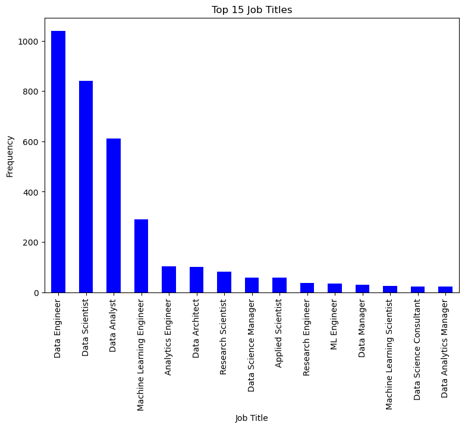

```python
#Counts the 15 most job titile frequency

job_title_frequency = data['job_title'].value_counts().head(15)

# Setting the plot size
plt.figure(figsize=(9, 6))

# Plotting the job_title and setting the colour blue
job_title_frequency.plot(kind='bar', color='blue')

# Adding label to the x-axis
plt.xlabel('Job Title')

# Adding label to the y-axis
plt.ylabel('Frequency')

# Adding title for the plot
plt.title('Top 15 Job Titles')

# Setting the rotation for x and y axis
plt.xticks(rotation = 90)
plt.yticks(rotation=0)

# Displays plot
plt.show()
```

● Which job has the highest salaries? Illustrate with bar graph.

[figure not shown]

```python
# Count the highest paying jobs
highest_salary_job = data.groupby('job_title').salary_in_usd.mean().sort_values().head(5)


# Setting the plot size
plt.figure(figsize=(9, 6))

# Plotting the job_title and setting the colour blue
highest_salary_job.plot(kind='bar', color='blue')

# Adding label to the x-axis
plt.xlabel('Job Title')

# Adding label to the y-axis
plt.ylabel('Salary')

# Adding title for the plot
plt.title('Highest Salaries')

# Setting the rotation for x and y axis
plt.xticks(rotation = 90)
plt.yticks(rotation=0)

# Displays plot
plt.show()
```

● Write a python program to find out salaries based on experience level. Illustrate it through bar graph.

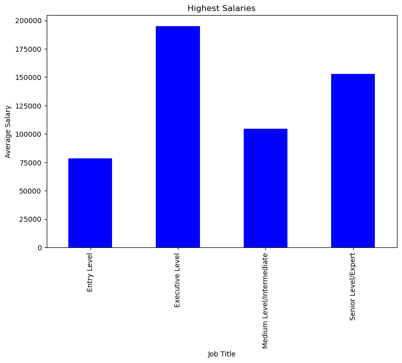

```python
# Find out the salaries based on experince level
average_experience_salary = data.groupby('experience_level')['salary_in_usd'].mean()


# Setting the plot size
plt.figure(figsize=(9, 6))

# Plotting the job_title and setting the colour blue
average_experience_salary.plot(kind='bar', color='blue')

# Adding label to the x-axis
plt.xlabel('Job Title')

# Adding label to the y-axis
plt.ylabel('Average Salary')

# Adding title for the plot
plt.title('Highest Salaries')

# Setting the rotation for x and y axis
plt.xticks(rotation = 90)
plt.yticks(rotation=0)

# Displays plot
plt.show()
```

● Write a Python program to show histogram and box plot of any chosen different variables. Use proper labels in the graph.

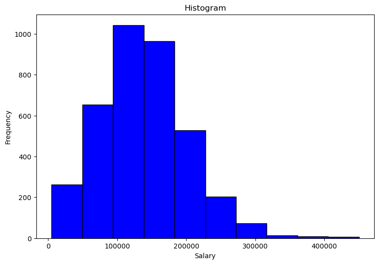

```python
#Salary in usd column
salary_histogram = data['salary_in_usd']

# Setting the plot size
plt.figure(figsize=(9, 6))

# Plotting a histogram for the salary DataFrame
plt.hist(salary_histogram,color='blue',edgecolor='black')

# Adding label to the x-axis
plt.xlabel('Salary')

# Adding label to the y-axis
plt.ylabel('Frequency')

# Adding title for the plot
plt.title('Histogram')


# Displays plot
plt.show()
```

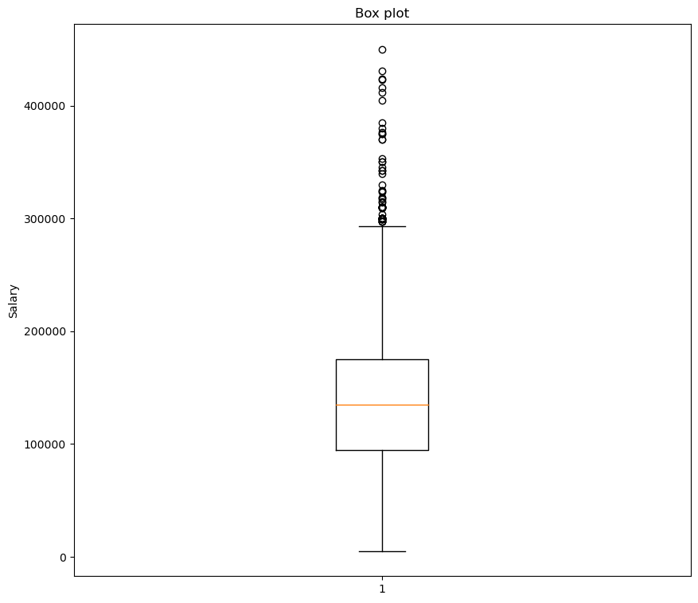

```python
#Salary in USD column
salary_box_plot = data['salary_in_usd']

# Setting the plot size
plt.figure(figsize=(10, 9))

# Plotting a boxplot for the salary
plt.boxplot(salary_box_plot)

# Adding label to the y-axis
plt.ylabel('Salary')

# Adding title for the plot
plt.title('Box plot')


# Displays plot
plt.show()
```